# Exercicio Aula 24

Davi Wentrick Feijó - 200016806

2023-07-11

# Experimento $2^3$

## Modelo utilizado

$$Y_{ijk} = \mu + \tau_i + \beta_j + \theta_k + (\tau\beta)_{ij} +
(\tau\theta)_{ik} + (\beta\theta)_{jk} + (\tau\beta\theta)_{ijk} +
\epsilon_{ijk}$$
onde:

- $\mu$ é a média
- $\tau_i$ é o efeito do i-ésimo nivel do fator A
- $\beta_j$ é o efeito do j-ésimo nivel do fator B
- $\theta_k$ é o efeito do k-ésimo nivel do fator C
- $(\tau\beta)_{ij}$ é o efeito da interacao entre A e B
- $(\tau\theta)_{ik}$ é o efeito da interacao entre A e C
- $(\beta\theta)_{jk}$ é o efeito da interacao entre B e C
- $(\tau\beta\theta)_{ijk}$ é o efeito da interacao entre A, B e C
- $\epsilon_{ijk}$ é o componente do erro aletorio

## Montando o banco de dados para analise

```r
# Vetores com os fatores
fatorA <- c("A baixo", "A alto")
fatorB <- c("B baixo", "B alto")
fatorC <- c("C baixo", "C alto")

# Gerar todas as combinações
matriz_combinacoes <- expand.grid(fatorA, fatorB, fatorC)
colnames(matriz_combinacoes) = c("A","B","C")
rep_1 = c(550,669,633,642,1037,749,1075,729)
rep_2 = c(604,650,601,635,1052,868,1063,860)


dados = data.frame(matriz_combinacoes,rep_1,rep_2) %>%
  mutate(total = rep_1 + rep_2)
```

```
##         A       B       C rep_1 rep_2 total
## 1 A baixo B baixo C baixo   550   604  1154
## 2  A alto B baixo C baixo   669   650  1319
## 3 A baixo  B alto C baixo   633   601  1234
## 4  A alto  B alto C baixo   642   635  1277
## 5 A baixo B baixo  C alto  1037  1052  2089
## 6  A alto B baixo  C alto   749   868  1617
## 7 A baixo  B alto  C alto  1075  1063  2138
## 8  A alto  B alto  C alto   729   860  1589
```

## Os efeitos principais dos fatores A, B, C, AB, AC, BC e ABC

```r
n = 2#numero de repeticoes

#calculando os efeitos

um = dados$total[1]
a = dados$total[2]
b = dados$total[3]
ab = dados$total[4]
c = dados$total[5]
ac = dados$total[6]
bc = dados$total[7]
abc = dados$total[8]

contrasteA = (a+ab+ac+abc-um-b-c-bc)
contrasteB = (b+ab+bc+abc-um-a-c-ac)
contrasteC = (c+ac+bc+abc-um-a-b-ab)
contrasteAB = (um-a-b+ab+c-ac-bc+abc)
contrasteAC = (um-a+b-ab-c+ac-bc+abc)
contrasteBC = (um+a-b-ab-c-ac+bc+abc)
contrasteABC = (abc-ac-bc+c-ab+a+b-um)

A = contrasteA/(4*n)

B = contrasteB/(4*n)

C = contrasteC/(4*n)

AB = contrasteAB/(4*n)

AC = contrasteAC/(4*n)

BC = contrasteBC/(4*n)

ABC = contrasteABC/(4*n)
```

```
## O efeito A é: -101.625
```

```
## O efeito B é: 7.375
```

```
## O efeito C é: 306.125
```

```
## O efeito AB é: -24.875
```

```
## O efeito AC é: -153.625
```

```
## O efeito BC é: -2.125
```

```
## O efeito ABC é: 5.625
```

## Calcule as seguintes somas de quadrados: SQA, SQB , SQC , SQAB , SQAC , SQBC , SQABC , SQT e SQRes

```r
#formatando o banco para futuras analises
dados_padronizado = dados %>%
  pivot_longer(cols = c(rep_1,rep_2), values_to = "values", names_to = "rep")
```

```
## # A tibble: 16 × 6
##    A       B       C       total rep   values
##    <fct>   <fct>   <fct>   <dbl> <chr>  <dbl>
##  1 A baixo B baixo C baixo  1154 rep_1    550
##  2 A baixo B baixo C baixo  1154 rep_2    604
##  3 A alto  B baixo C baixo  1319 rep_1    669
##  4 A alto  B baixo C baixo  1319 rep_2    650
##  5 A baixo B alto  C baixo  1234 rep_1    633
##  6 A baixo B alto  C baixo  1234 rep_2    601
##  7 A alto  B alto  C baixo  1277 rep_1    642
##  8 A alto  B alto  C baixo  1277 rep_2    635
##  9 A baixo B baixo C alto   2089 rep_1   1037
## 10 A baixo B baixo C alto   2089 rep_2   1052
## 11 A alto  B baixo C alto   1617 rep_1    749
## 12 A alto  B baixo C alto   1617 rep_2    868
## 13 A baixo B alto  C alto   2138 rep_1   1075
## 14 A baixo B alto  C alto   2138 rep_2   1063
## 15 A alto  B alto  C alto   1589 rep_1    729
## 16 A alto  B alto  C alto   1589 rep_2    860
```

```r
#soma de quadrados
SQA = (contrasteA^2)/(8*n)
SQB = (contrasteB^2)/(8*n)
SQC = (contrasteC^2)/(8*n)
SQAB = (contrasteAB^2)/(8*n)
SQAC = (contrasteAC^2)/(8*n)
SQBC = (contrasteBC^2)/(8*n)
SQABC = (contrasteABC^2)/(8*n)
SQtot = sum((dados_padronizado$values - mean(dados_padronizado$values))^2)
SQres = SQtot - (SQA+SQB+SQC+SQAB+SQAC+SQBC+SQABC)
```

```
## A soma de quadrados de A é: 41310.56
```

```
## A soma de quadrados de B é: 217.5625
```

```
## A soma de quadrados de C é: 374850.1
```

```
## A soma de quadrados de AB é: 2475.062
```

```
## A soma de quadrados de AC é: 94402.56
```

```
## A soma de quadrados de BC é: 18.0625
```

```
## A soma de quadrados de ABC é: 126.5625
```

```
## A soma de quadrados do residuo é: 18020.5
```

```
## A soma de quadrados total é: 531420.9
```

## Os respectivos graus de liberdade.

```r
#graus de liberdade
a = length(unique(dados_padronizado$A))
b = length(unique(dados_padronizado$B))
c = length(unique(dados_padronizado$C))
r = length(unique(dados_padronizado$rep))

glA <- a - 1
glB <- b - 1
glC <- c - 1
glAB <- (a-1)*(b-1)
glAC <- (a-1)*(c-1)
glBC <- (b-1)*(c-1)
glABC <- (a-1)*(b-1)*(c-1)
glRES <- a*b*c*(r-1)
glTOT = (8*n-1)
```

```
## Os graus de liberdade de A é: 1
```

```
## Os graus de liberdade de B é: 1
```

```
## Os graus de liberdade de C é: 1
```

```
## Os graus de liberdade de AB é: 1
```

```
## Os graus de liberdade de AC é: 1
```

```
## Os graus de liberdade de BC é: 1
```

```
## Os graus de liberdade de ABC é: 1
```

[output not shown]

[output not shown]

## Construa a Tabela ANOVA.

```r
#quadrados medios
qmA = SQA/glA
qmB = SQB/glB
qmC = SQC/glC
qmAB = SQAB/glAB
qmAC = SQAC/glAC
qmBC = SQBC/glBC
qmABC = SQABC/glABC
qmres = SQres/glRES

# valor F observado
f_obs_A = qmA/qmres
f_obs_B = qmB/qmres
f_obs_C = qmC/qmres
f_obs_AB = qmAB/qmres
f_obs_AC = qmAC/qmres
f_obs_BC = qmBC/qmres
f_obs_ABC = qmABC/qmres

#p-valor observado
f_value_A = round(pf(f_obs_A,glA,glRES,lower.tail = FALSE),7)
f_value_B = round(pf(f_obs_B,glB,glRES,lower.tail = FALSE),7)
f_value_C = round(pf(f_obs_C,glC,glRES,lower.tail = FALSE),7)
f_value_AB = round(pf(f_obs_AB,glAB,glRES,lower.tail = FALSE),7)
f_value_AC = round(pf(f_obs_AC,glAC,glRES,lower.tail = FALSE),7)
f_value_BC = round(pf(f_obs_BC,glBC,glRES,lower.tail = FALSE),7)
f_value_ABC = round(pf(f_obs_ABC,glABC,glRES,lower.tail = FALSE),7)
```

Nossa tabela anova com os resultados calculados manualmente

```
##   Fonte_de_variacao GL       SS       MQ       F       Pf
## 1           Fator A  1  41310.6  41310.6  18.339 0.002679
## 2           Fator B  1    217.6    217.6   0.097 0.763911
## 3           Fator C  1 374850.1 374850.1 166.411 0.000001
## 4               A:B  1   2475.1   2475.1   1.099 0.325168
## 5               A:C  1  94402.6  94402.6  41.909 0.000193
## 6               B:C  1     18.1     18.1   0.008 0.930849
## 7             A:B:C  1    126.6    126.6   0.056 0.818586
## 8           Residuo  8  18020.5   2252.6   0.000 0.000000
## 9             Total 15 531420.9      0.0   0.000 0.000000
```

Podemos comparar com a função `aov()` do R

```r
modelo = aov(values ~ A*B*C, data = dados_padronizado)
summary(modelo)
```

```
##             Df Sum Sq Mean Sq F value   Pr(>F)
## A            1  41311   41311  18.339 0.002679 **
## B            1    218     218   0.097 0.763911
## C            1 374850  374850 166.411 1.23e-06 ***
## A:B          1   2475    2475   1.099 0.325168
## A:C          1  94403   94403  41.909 0.000193 ***
## B:C          1     18      18   0.008 0.930849
## A:B:C        1    127     127   0.056 0.818586
## Residuals    8  18020    2253
## ---
## Signif. codes:  0 '***' 0.001 '**' 0.01 '*' 0.05 '.' 0.1 ' ' 1
```

## Pressupostos

### Normalidade

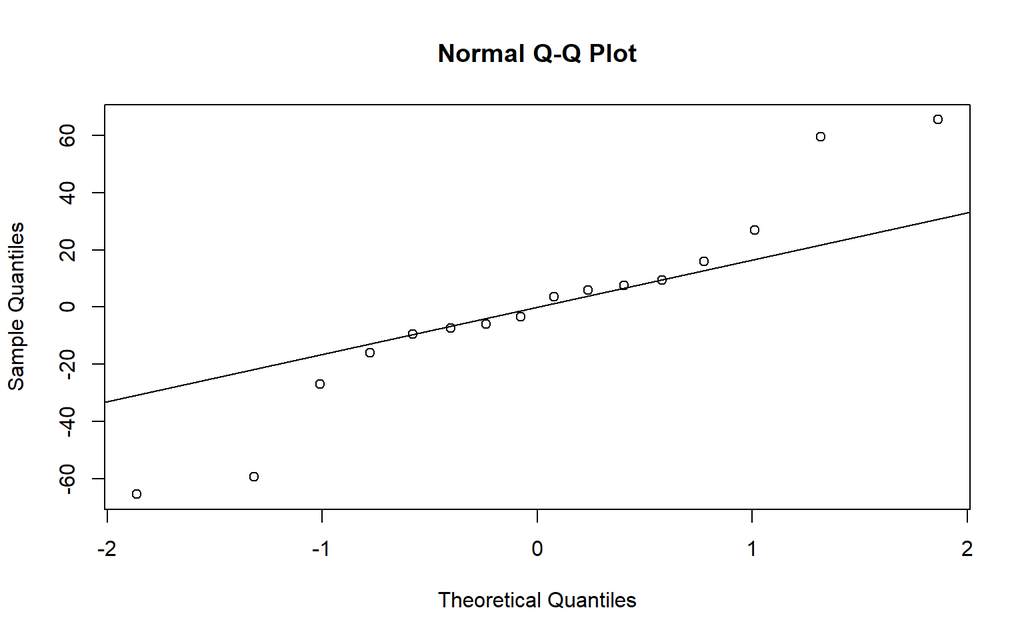

```r
residuo = modelo$residuals
#normalidade
qqnorm(residuo)
qqline(residuo)
```

```r
shapiro.test(residuo)
```

```
##
##  Shapiro-Wilk normality test
##
## data:  residuo
## W = 0.94261, p-value = 0.3823
```

### Independencia

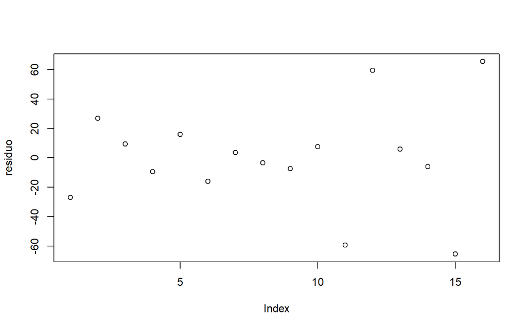

```r
#independencia

plot(residuo)
```

### Homocedasticidade

```r
#homocedasticidade

leveneTest(values ~ A ,data = dados_padronizado)
```

```
## Levene's Test for Homogeneity of Variance (center = median)
##       Df F value    Pr(>F)
## group  1  49.134 6.154e-06 ***
##       14
## ---
## Signif. codes:  0 '***' 0.001 '**' 0.01 '*' 0.05 '.' 0.1 ' ' 1
```

Pelo teste de Levene com 5% de significância, rejeita-se h0. Logo, variâncias não são iguais em relacao ao fator A.

```r
leveneTest(values ~ B ,data = dados_padronizado)
```

```
## Levene's Test for Homogeneity of Variance (center = median)
##       Df F value Pr(>F)
## group  1   0.001 0.9755
##       14
```

```r
leveneTest(values ~ C ,data = dados_padronizado)
```

```
## Levene's Test for Homogeneity of Variance (center = median)
##       Df F value    Pr(>F)
## group  1  22.077 0.0003421 ***
##       14
## ---
## Signif. codes:  0 '***' 0.001 '**' 0.01 '*' 0.05 '.' 0.1 ' ' 1
```

Pelo teste de Levene com 5% de significância, rejeita-se h0. Logo, variâncias não são iguais em relacao ao fator C.

Vamos testar em relacao as interacoes entre os fatores

```r
leveneTest(values ~ A:B ,data = dados_padronizado)
```

```
## Levene's Test for Homogeneity of Variance (center = median)
##       Df F value    Pr(>F)
## group  3  15.222 0.0002158 ***
##       12
## ---
## Signif. codes:  0 '***' 0.001 '**' 0.01 '*' 0.05 '.' 0.1 ' ' 1
```

```r
leveneTest(values ~ A:C ,data = dados_padronizado)
```

```
## Levene's Test for Homogeneity of Variance (center = median)
##       Df F value    Pr(>F)
## group  3  11.222 0.0008497 ***
##       12
## ---
## Signif. codes:  0 '***' 0.001 '**' 0.01 '*' 0.05 '.' 0.1 ' ' 1
```

```r
leveneTest(values ~ B:C ,data = dados_padronizado)
```

```
## Levene's Test for Homogeneity of Variance (center = median)
##       Df F value   Pr(>F)
## group  3  7.1034 0.005327 **
##       12
## ---
## Signif. codes:  0 '***' 0.001 '**' 0.01 '*' 0.05 '.' 0.1 ' ' 1
```

```r
leveneTest(values ~ A:B:C ,data = dados_padronizado)
```

```
## Levene's Test for Homogeneity of Variance (center = median)
##       Df    F value    Pr(>F)
## group  7 4.0541e+31 < 2.2e-16 ***
##        8
## ---
## Signif. codes:  0 '***' 0.001 '**' 0.01 '*' 0.05 '.' 0.1 ' ' 1
```

Pelo teste de Levene com 5% de significância, rejeita-se h0 em todas as interacoes entre os fatores. Logo, variâncias não são iguais.

## Interprete os resultados encontrados nos itens anteriores.